# GR5072 Modern Data Structures_HW 3

Bolim Son

October 3rd, 2019

```r
# Set working directory
setwd("C:/Users/bolim/OneDrive/Documents/GitHub/Son_Bolim/HW_03")
```

## **`for` Loops & Functions**

### **1. Monkey song**

**a) Write a loop**

Write a for loop that will iterate the main verse from 10 to 1. End with the last verse.

```r
# Write a loop
# Default: prints 10 to 1 and ends with last verse

n <- 0

for(n in 10:n)
if(n > 1){
  cat(
    n, "little monkeys jumping on the bed,
One fell down and bumped his head,
Mama called the doctor and the doctor said,
\"No more monkeys jumping on the bed!\"", "\n"
  )
  cat(sep ="\n")
  } else if(n == 1){
  cat(
    n, "little monkey jumping on the bed,
One fell down and bumped his head,
Mama called the doctor and the doctor said,
\"No more monkeys jumping on the bed!\"", "\n"
  )
  cat(sep ="\n")
  } else {
    cat(
    "No little monkeys jumping on the bed,
None fell down and bumped their head,
Papa called the doctor and the doctor said,
\"Put those monkeys right to bed!\"", "\n"
    )
  }
```

Print steps 10 to 8 (that is from 10 monkeys to 8 monkeys) to the console. Show the loop code and the print output in your solution. (Hint: the cat() function may be useful to concatenate the output you want.)

```r
# Print steps 10 to 8

n <- 8

for(n in 10:n)
if(n > 1){
  cat(
    n, "little monkeys jumping on the bed,
One fell down and bumped his head,
Mama called the doctor and the doctor said,
\"No more monkeys jumping on the bed!\"", "\n"
  )
  cat(sep ="\n")
  } else if(n == 1){
  cat(
    n, "little monkey jumping on the bed,
One fell down and bumped his head,
Mama called the doctor and the doctor said,
\"No more monkeys jumping on the bed!\"", "\n"
  )
  cat(sep ="\n")
  } else {
    cat(
    "No little monkeys jumping on the bed,
None fell down and bumped their head,
Papa called the doctor and the doctor said,
\"Put those monkeys right to bed!\"", "\n"
    )
  }
```

```
## 10 little monkeys jumping on the bed,
## One fell down and bumped his head,
## Mama called the doctor and the doctor said,
## "No more monkeys jumping on the bed!"
##
## 9 little monkeys jumping on the bed,
## One fell down and bumped his head,
## Mama called the doctor and the doctor said,
## "No more monkeys jumping on the bed!"
##
## 8 little monkeys jumping on the bed,
## One fell down and bumped his head,
## Mama called the doctor and the doctor said,
## "No more monkeys jumping on the bed!"
```

**b) Convert loop to a function**

Now convert the loop into a function. Generalize to any type of animal and a variable number of them (but assume the number of animals entered is larger or equal to 3). Set the default values of your function arguments to the original song. Show the function code in your solution and print the output using the following values: 3, Piglet.

```r
# Create a function
animal_song <- function(n=10, animal_name="monkey") { # Default start from 10 animals, animal default to monkeys
  animal_name <- rlang::as_string(animal_name)
  animal_name_pl <- paste(animal_name, "s", sep ="")
for(n in n:0)
if(n > 1){
  cat(
    n, "little", animal_name_pl,"jumping on the bed,
One fell down and bumped his head,
Mama called the doctor and the doctor said,
\"No more", animal_name_pl,"jumping on the bed!\"", "\n"
  )
  cat(sep ="\n")
  } else if(n == 1) {
  cat(
    n, "little", animal_name, "jumping on the bed,
One fell down and bumped his head,
Mama called the doctor and the doctor said,
\"No more", animal_name_pl, "jumping on the bed!\"", "\n"
  )
  cat(sep ="\n")
  } else {
    cat(
    "No little", animal_name, "jumping on the bed,
None fell down and bumped their head,
Papa called the doctor and the doctor said,
\"Put those", animal_name_pl, "right to bed!\"", "\n"
    )
    cat(sep ="\n")
  }
}

# Input values
animal_song(n=3, animal_name = "piglet")
```

```
## 3 little piglets jumping on the bed,
## One fell down and bumped his head,
## Mama called the doctor and the doctor said,
## "No more piglets jumping on the bed!"
##
## 2 little piglets jumping on the bed,
## One fell down and bumped his head,
## Mama called the doctor and the doctor said,
## "No more piglets jumping on the bed!"
##
## 1 little piglet jumping on the bed,
## One fell down and bumped his head,
## Mama called the doctor and the doctor said,
## "No more piglets jumping on the bed!"
##
## No little piglet jumping on the bed,
## None fell down and bumped their head,
## Papa called the doctor and the doctor said,
## "Put those piglets right to bed!"
```

**c) Add error check**

Add an error check to produce a warning when a user passes a non-numeric input to the number of animals.

```r
# Add error check in the function
animal_song <- function(n=10, animal_name="monkey") {
# Add warning
  if(is.numeric(n) == FALSE) stop('For n, enter integer from 3 to 10')
  animal_name <- rlang::as_string(animal_name)
  animal_name_pl <- paste(animal_name, "s", sep ="")
for(n in n:0)
if(n > 1){
  cat(
    n, "little", animal_name_pl,"jumping on the bed,
One fell down and bumped his head,
Mama called the doctor and the doctor said,
\"No more", animal_name_pl,"jumping on the bed!\"", "\n"
  )
  cat(sep ="\n")
  } else if(n == 1) {
  cat(
    n, "little", animal_name, "jumping on the bed,
One fell down and bumped his head,
Mama called the doctor and the doctor said,
\"No more", animal_name_pl, "jumping on the bed!\"", "\n"
  )
  cat(sep ="\n")
  } else {
    cat(
    "No little", animal_name, "jumping on the bed,
None fell down and bumped their head,
Papa called the doctor and the doctor said,
\"Put those", animal_name_pl, "right to bed!\"", "\n"
    )
    cat(sep ="\n")
  }
}


# Test error sign
animal_song(n = "ap", animal_name = "cat")
```

```
## Error in animal_song(n = "ap", animal_name = "cat"): For n, enter integer from 3 to 10
```

**d) BONUS (optional): Convert loop to a fully generalized function**

Generalize to any number (i.e no longer assume a minimum of 3) of any animal involved in any activity (that is ‘hopping’, ‘bouncing’, ‘skipping’ etc.) on the bed. For equality, also randomize whether mama or papa calls the doctor each time with the probability of the binary choice as a parameter. Set the default values of your function arguments to the original song. Show the function code in your solution and print the output using the following values: num=3, animal=kangaroo, activity=dancing, probability=0.5.

```r
# Create a fully generalized function
animal_song <- function(n=10, animal_name = "monkey", activity = "jumping", probability = 0.5) {
  if(is.numeric(n) == FALSE) stop('For n, enter integer from 3 to 10')
  if (n < 3) stop('n must be bigger than 3')
  animal_name <- rlang::as_string(animal_name)
  animal_name_pl <- paste(animal_name, "s", sep ="")

  # Another function inside a function to choose parent from
  parent <- function(x=1){
    sample(c("Mama", "Papa"), x, prob = c(probability, 1-probability))
  }

for(n in n:0)
  if(n > 1){
  cat(
     n,"little", animal_name_pl, activity, "on the bed,\n One fell down and bumped his head,\n", parent(), "called the doctor and the doctor said,\n \"No more", animal_name_pl, activity, "on the bed!\"", "\n"
  )
  cat(sep ="\n")
  } else if(n == 1) {
  cat(
    n, "little", animal_name, activity, "on the bed,\n One fell down and bumped his head,\n",parent(), "called the doctor and the doctor said,\n \"No more", animal_name_pl, activity, "on the bed!\"", "\n"
  )
  cat(sep ="\n")
  } else {
    cat(
    "No little", animal_name, activity, "on the bed,\n None fell down and bumped their head,\n",parent(), "called the doctor and the doctor said,\n \"Put those", animal_name_pl, "right to bed!\"", "\n"
    )
    cat(sep ="\n")
  }
}

# Test function with num=3, animal=kangaroo, activity=dancing, probability=0.5
animal_song(n = 3, animal_name = "kangaroo", activity = "dancing", probability = 0.5)
```

```
## 3 little kangaroos dancing on the bed,
##  One fell down and bumped his head,
##  Mama called the doctor and the doctor said,
##  "No more kangaroos dancing on the bed!"
##
## 2 little kangaroos dancing on the bed,
##  One fell down and bumped his head,
##  Mama called the doctor and the doctor said,
##  "No more kangaroos dancing on the bed!"
##
## 1 little kangaroo dancing on the bed,
##  One fell down and bumped his head,
##  Papa called the doctor and the doctor said,
##  "No more kangaroos dancing on the bed!"
##
## No little kangaroo dancing on the bed,
##  None fell down and bumped their head,
##  Mama called the doctor and the doctor said,
##  "Put those kangaroos right to bed!"
```

### **2. Draw a plot using a loop**

**a) Plot with horizontal lines**

Initialize a plot. Add 11 horizontal lines (from 0 to 10) using a for loop. Show the code of the loop and the plot in the output.

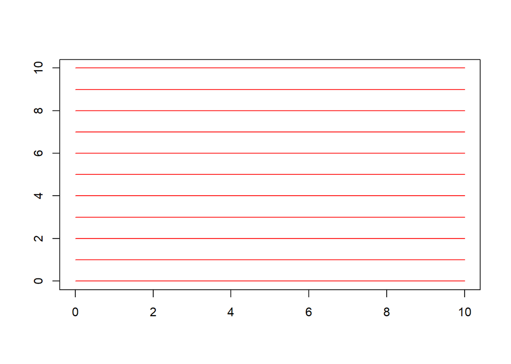

```r
# Initialize a plot
plot(1, type = "n", xlab = "", ylab = "", xlim = c(0, 10), ylim = c(0, 10))

# For loop
for(n in 0:10)
lines(x = c(0, 10), y = c(n, n), col = "red")
```

**b) Add vertical lines**

Extend the previous code, but now also add 11 vertical lines. Show the code and the changed plot in the output.

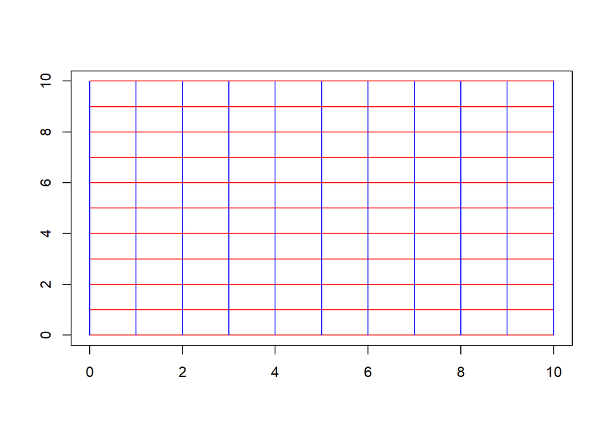

```r
# Initialize a plot
plot(1, type = "n", xlab = "", ylab = "", xlim = c(0, 10), ylim = c(0, 10))

# For loop
for(n in 0:10){
lines(x = c(0, 10), y = c(n, n), col = "red") # Horizontal
lines(x = c(n, n), y = c(0, 10), col = "blue") # Vertical
}
```

**c) Add points**

Lastly, add points() to the plot to all coordinate points where the lines intersect on the diagonals (that is the 45 and -45 degree lines). E.g. x=1,y=1 … x=1,y=9 etc. Again, show the code and the changed plot output.

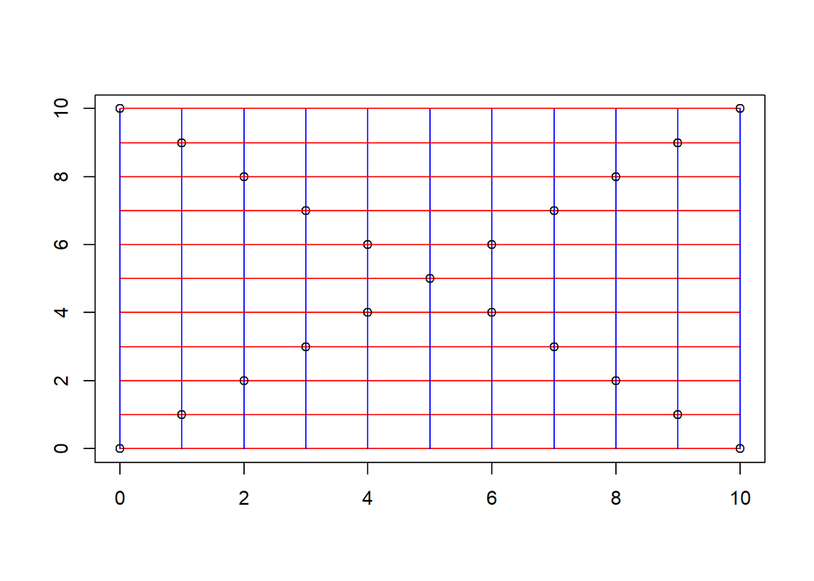

```r
# Initialize a plot
plot(1, type = "n", xlab = "", ylab = "", xlim = c(0, 10), ylim = c(0, 10))

# For loop
for(n in 0:10){
  lines(x = c(0, 10), y = c(n, n), col = "red") # Horizontal
  lines(x = c(n, n), y = c(0, 10), col = "blue") # Vertical
  points(x = c(n, n), y = c(n, n)) # 45 degree points
  points(x = c(n, n), y = c(10-n, 10-n)) # -45 degree points
}
```

**d) Convert to function**

Convert this into a function that will allow the user to set the size of the plot (the plot should be square) and which items to draw (horizontal lines, vertical lines, points on the diagonal). Show the function you have written but no other output. Make sure the arguments of the function are set to sensible default values.

```r
# Create a function, default for n is 10 and for drawing is all TRUE
plot_function <- function(n = 10, horizontal = TRUE, vertical = TRUE, points = TRUE){
plot(1, type = "n", xlab = "", ylab = "", xlim = c(0, n), ylim = c(0, n))
  for(a in 0:n){
  if(horizontal == TRUE){
      lines(x = c(0, n), y = c(a, a))
    }
  if(vertical == TRUE){
      lines(x = c(a, a), y = c(0, n))
  }
  if(points == TRUE){
    points(x = c(a, a), y = c(a, a))
    points(x = c(a, a), y = c(n-a, n-a))
  }
  }
}

# Example of plot function
plot_function(n = 5, horizontal = TRUE, vertical = FALSE, points = TRUE)
```

## **Descriptive Statistics of a Vector with Error Checks (Optional)**

Write a desc_stats() function that calculates some descriptive statistics for a vector.

**a) Calculate min and max** Write a function that takes a vector as input and prints its minimum and maximum. Make sure to remove any NAs from the vector before the calculations.

```r
# Create a vector with numbers and NA
ex_vector <- c(1, 2, 3, 4, 5, 6, 7, 8, 9, NA)

# Write a function
desc_stats <- function(x) {
  max_n <- max(x, na.rm = TRUE)
  min_n <- min(x, na.rm = TRUE)
  result <- data.frame(values = c(max_n, min_n), row.names = c("max", "min"))
  print(result)
}

# Print results
desc_stats(x = ex_vector)
```

```
##     values
## max      9
## min      1
```

**b) Add the median** Add an additional argument to the function (set to FALSE by default) that will allow a user to calculate the median of the vector as well. If the median is calculated, round it to two digits (hint: use the function round()).

```r
# Add median

desc_stats <- function(x, median_n = FALSE) {
  max_n <- max(x, na.rm = TRUE)
  min_n <- min(x, na.rm = TRUE)
if(median_n == TRUE){
  median_n <- median(x, na.rm = TRUE)
  median_n <- round(median_n, digits = 2)
  result <- data.frame(values = c(max_n, min_n, median_n), row.names = c("max", "min", "median"))
  print(result)
} else {
  result <- data.frame(values = c(max_n, min_n), row.names = c("max", "min"))
  print(result)
}
}

desc_stats(x = ex_vector, median_n = TRUE)
```

```
##        values
## max         9
## min         1
## median      5
```

**c) Add error checks** Try your function on an empty vector z1 <- c() and a vector containing only NAs. You probably get a rather cryptic error. Alter your function so that it stops when a user supplies an empty vector or a vector with only NAs and gives a short warning about the issue. I suggest to use the return() function for this as the first step of your function.

```r
# Try out with empty vector and vectors with only NA
z1 <- c()
desc_stats(x = z1)
```

```
## Warning in max(x, na.rm = TRUE): no non-missing arguments to max; returning
## -Inf
```

```
## Warning in min(x, na.rm = TRUE): no non-missing arguments to min; returning
## Inf
```

```
##     values
## max   -Inf
## min    Inf
```

```r
z2<- c(NA, NA)
desc_stats(x = z2)
```

```
##     values
## max   -Inf
## min    Inf
```

```r
# Alter function, add warning message
desc_stats <- function(x, median_n = FALSE) {
# Vector error message
  if(length(x) == 0 | all(is.na(x) == TRUE)){return('Error: need a vector with numerical values, this vector has no values or only has NA')}
  break
# Otherwise, run the function
  max_n <- max(x, na.rm = TRUE)
  min_n <- min(x, na.rm = TRUE)
if(median_n == TRUE){
  median_n <- median(x, na.rm = TRUE)
  median_n <- round(median_n, digits = 2)
  result <- data.frame(values = c(max_n, min_n, median_n), row.names = c("max", "min", "median"))
  print(result)
} else {
  result <- data.frame(values = c(max_n, min_n), row.names = c("max", "min"))
  print(result)
}}

# Test
desc_stats(x = z1)
```

```
## [1] "Error: need a vector with numerical values, this vector has no values or only has NA"
```

```r
desc_stats(x = z2)
```

```
## [1] "Error: need a vector with numerical values, this vector has no values or only has NA"
```